# AS2019468UAE

Malindu Nimalsiri

10/2/2022

# Covid 19 in United Arab Emirates

The United Arab Emirates (UAE), or simply the Emirates, is a country in Western Asia. It is located at the eastern end of the Arabian Peninsula and shares borders with Oman and Saudi Arabia, while having maritime borders in the Persian Gulf with Qatar and Iran.

The first corona virus case in UAE was confirmed on 29 January in a family of four who arrived from Wuhan. The remaining three also tested positive for the virus later.

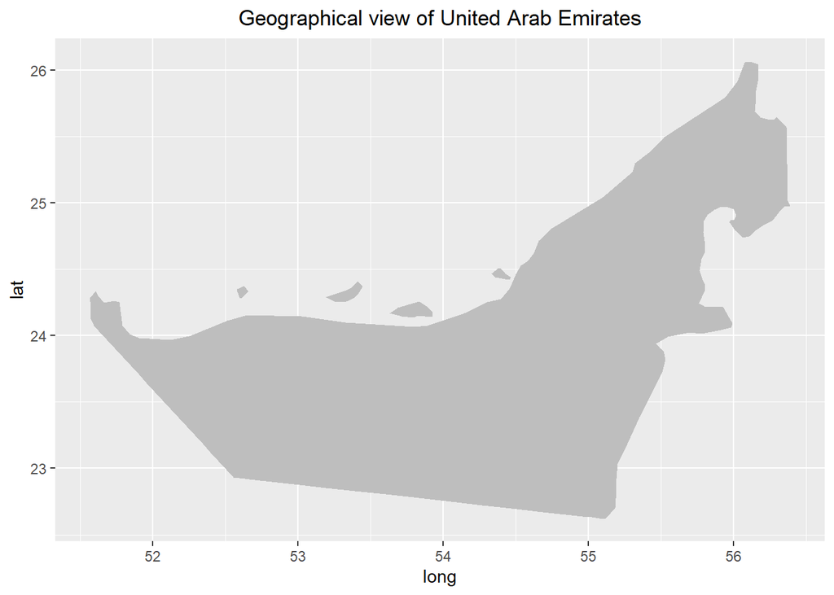

# Exploratory Data Analysis

## Content of Data

The data set contains the daily summery of Corona virus cases (confirmed, death and recovered), by state/province. This data set provided by Johns Hopkins University Center for Systems Science and Engineering

This data frame has included 15 variables

- Date : Date in YYYY-MM-DD format
- Province : Name of province/state, for countries where data is provided split across multiple provinces/states.
- Country : Name of country/region.
- lat : Latitude of center of geographic region, defined as either country or, if available, province.
- long : Longitude of center of geographic region, defined as either country or, if available, province.
- type : An indicator for the type of cases (confirmed, death, recovered).
- cases : Number of cases on given date.
- uid : Country code
- iso2 : Officially assigned country code identifiers with two-letter
- iso3 : Officially assigned country code identifiers with three-letter
- code3 : UN country code
- combined_key : Country and province (if applicable)
- population : Country or province population
- continent_name : Continent name
- continent_code : Continent code

## Descriptive data analysis for all cases

```
## # A tibble: 3 x 6
##   type         mean median   max      sd      n
##   <chr>       <dbl>  <dbl> <int>   <dbl>  <int>
## 1 confirmed 1056.     784.  4471  946.   933688
## 2 death        2.61     2     20    3.28   2309
## 3 recovery   752.     198   5059 1023.   664130
```

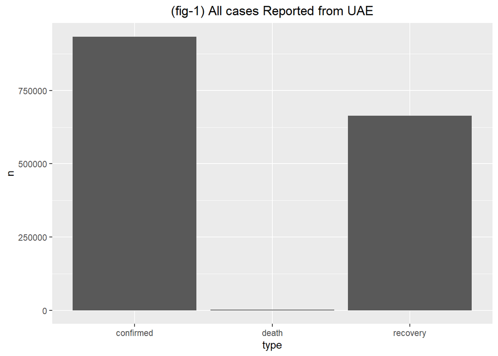

## Covid-19 confirmed cases

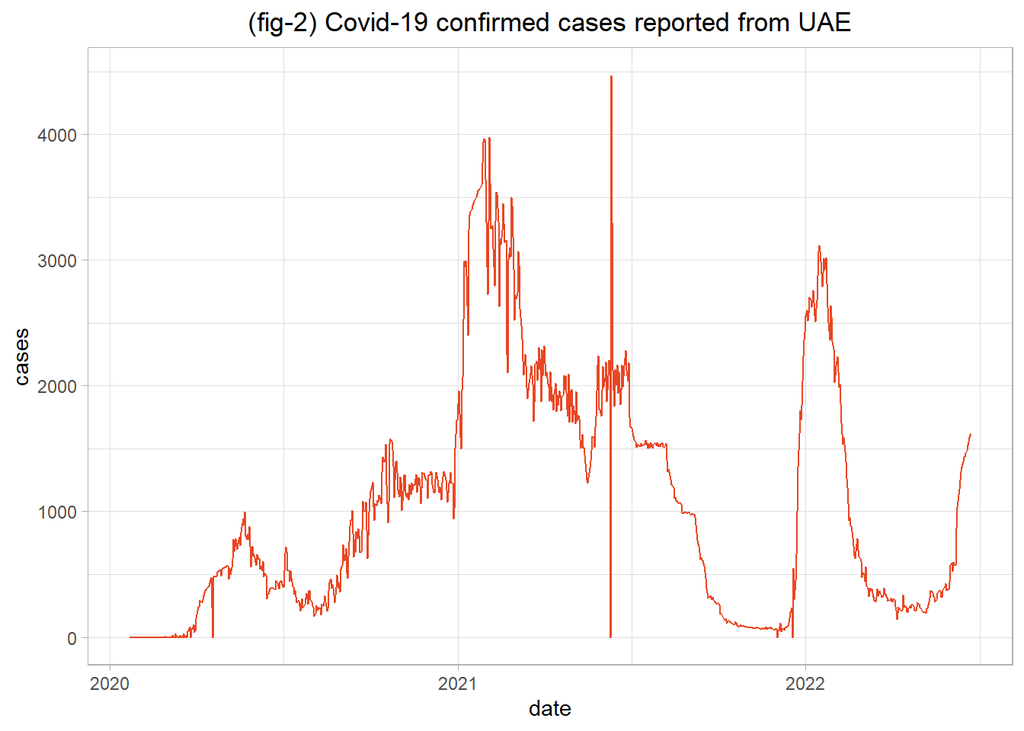

## Covid-19 death cases

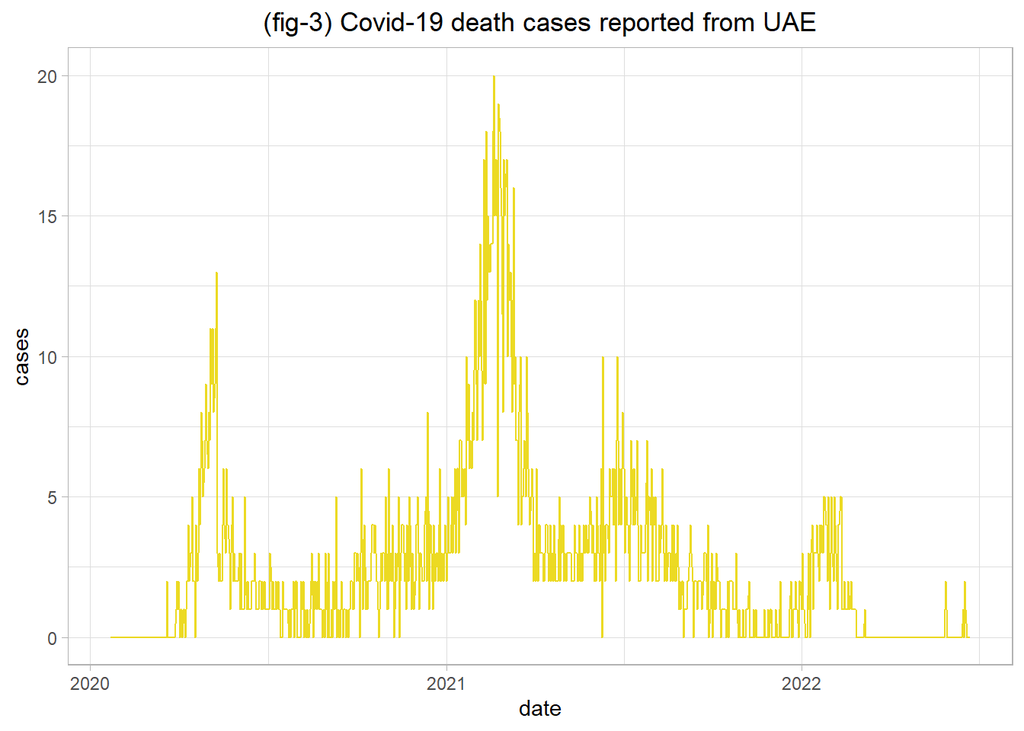

## Covid-19 recovery cases

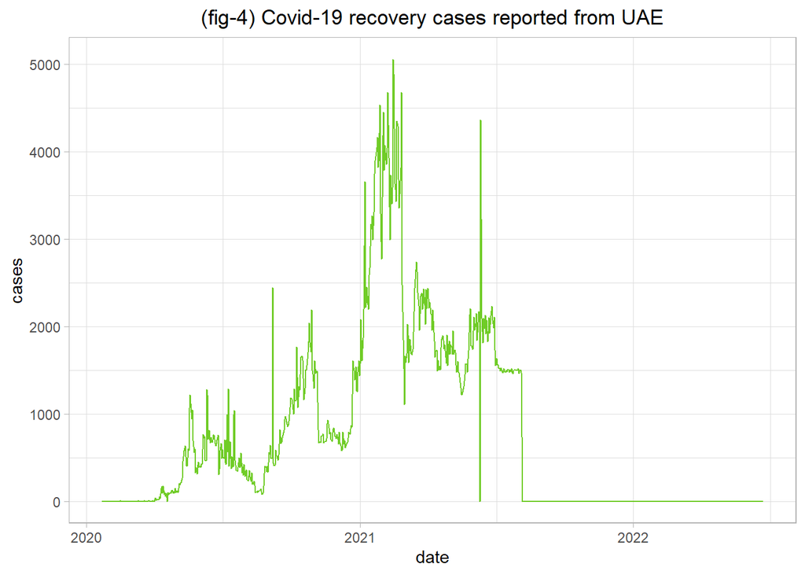

## Comparison with other countries

### Comparison with neighbourhood countries

United Arab Emirates shares borders with Oman and Saudi Arabia, while having maritime borders in the Persian Gulf with Qatar and Iran.Therefore we can identify how COVID-19 virus spread with nearest countries and how the government controlled the virus than other countries

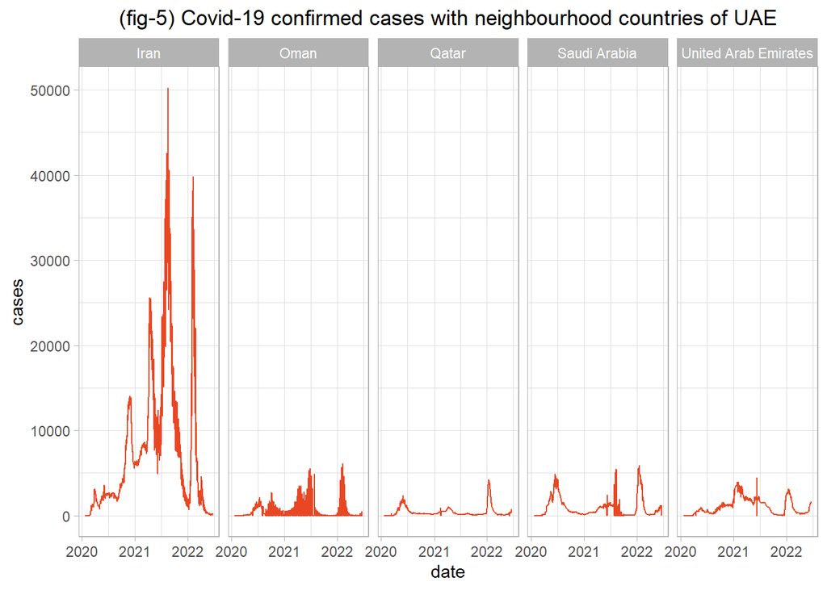

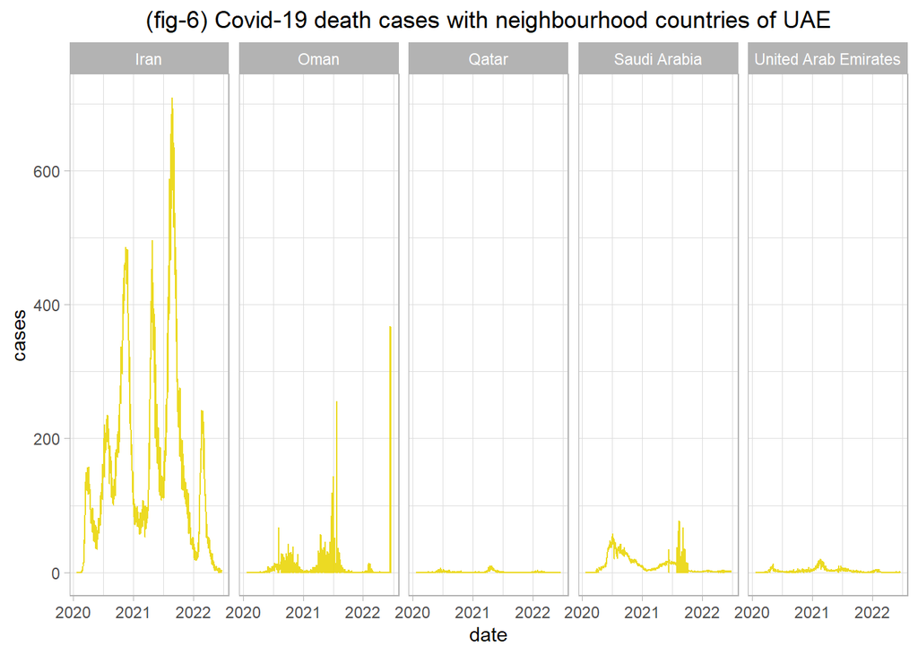

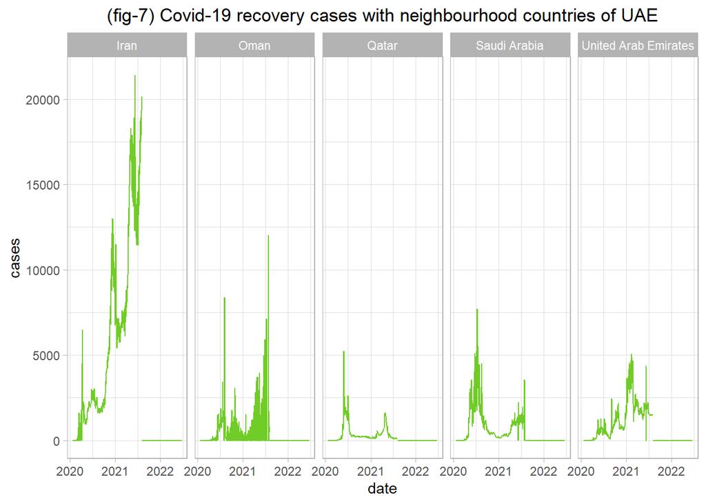

# Conclusion and discussion

The coronavirus disease continues to spread across the world following a trajectory that is difficult to predict.

# Reference

[r graph gallery](https://r-graph-gallery.com/)  
[United Arab emirates - Minister of health](https://mohap.gov.ae/en/covid-19)